# Kishor_Abhigyan_Project

Abhigyan Kishor

2023-11-03

This example uses the `tidyverse` suite of packages.

```r
library(tidyverse)
```

```r
library(ggplot2)
library(patchwork)
library(corrplot)
```

### Read data

The code chunk below reads in the final project data.

```r
df <- readr::read_csv("paint_project_train_data.csv", col_names = TRUE)
df %>% glimpse()
```

```
## Rows: 835
## Columns: 8
## $ R          <dbl> 172, 26, 172, 28, 170, 175, 90, 194, 171, 122, 0, 88, 144, …
## $ G          <dbl> 58, 88, 94, 87, 66, 89, 78, 106, 68, 151, 121, 140, 82, 163…
## $ B          <dbl> 62, 151, 58, 152, 58, 65, 136, 53, 107, 59, 88, 58, 132, 50…
## $ Lightness  <chr> "dark", "dark", "dark", "dark", "dark", "dark", "dark", "da…
## $ Saturation <chr> "bright", "bright", "bright", "bright", "bright", "bright",…
## $ Hue        <dbl> 4, 31, 8, 32, 5, 6, 34, 10, 1, 21, 24, 22, 36, 16, 26, 12, …
## $ response   <dbl> 12, 10, 16, 10, 11, 16, 10, 19, 14, 25, 14, 19, 14, 38, 15,…
## $ outcome    <dbl> 1, 1, 1, 0, 0, 0, 0, 0, 0, 0, 0, 0, 0, 0, 0, 0, 0, 0, 1, 1,…
```

The data consist of continuous and categorical inputs. The `glimpse()` shown above reveals the data type for each variable which state to you whether the input is continuous or categorical. The RGB color model inputs, `R`, `G`, and `B` are continuous (dbl) inputs. The HSL color model inputs consist of 2 categorical inputs, `Lightness` and `Saturation`, and a continuous input, `Hue`. Two outputs are provided. The continuous output, `response`, and the Binary output, `outcome`. However, the data type of the Binary outcome is numeric because the Binary `outcome` is **encoded** as `outcome = 1` for the EVENT and `outcome = 0` for the NON-EVENT.

## Phase 1: Data Exploration

### Visualize distributions of the dataset

#### Density/Histograms for continuous variables

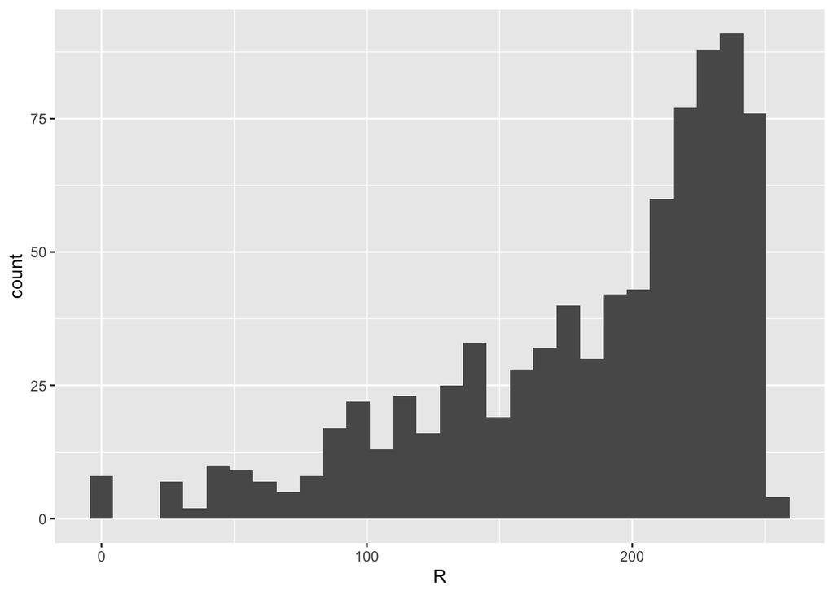

```r
df %>% ggplot(aes(x = R)) + geom_histogram()
```

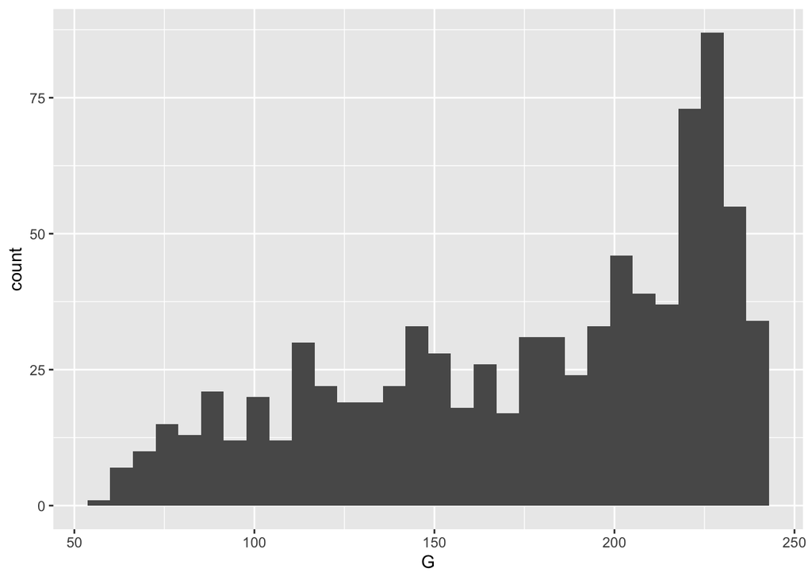

```r
df %>% ggplot(aes(x = G)) + geom_histogram()
```

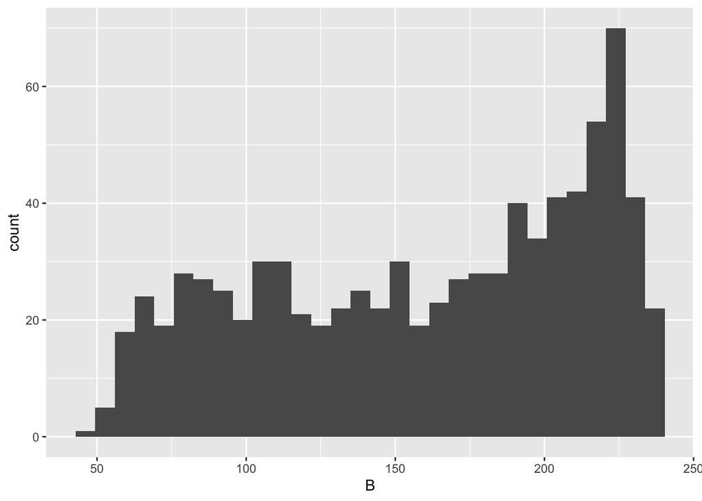

```r
df %>% ggplot(aes(x = B)) + geom_histogram()
```

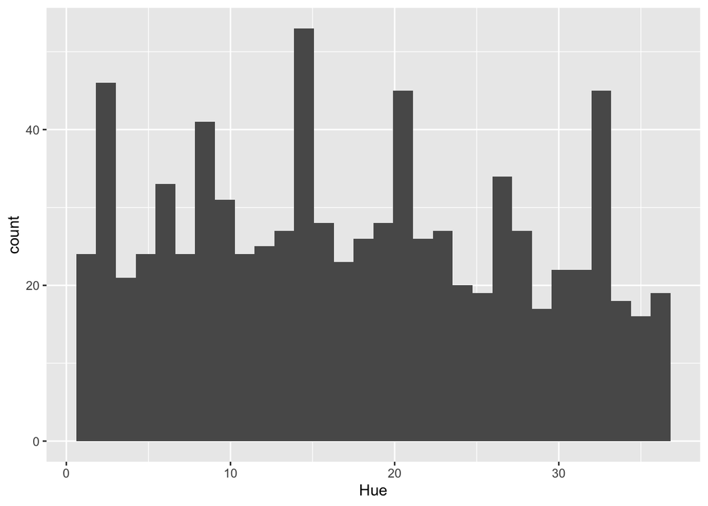

```r
df %>% ggplot(aes(x = Hue)) + geom_histogram()
```

#### Counting the categorical variables.

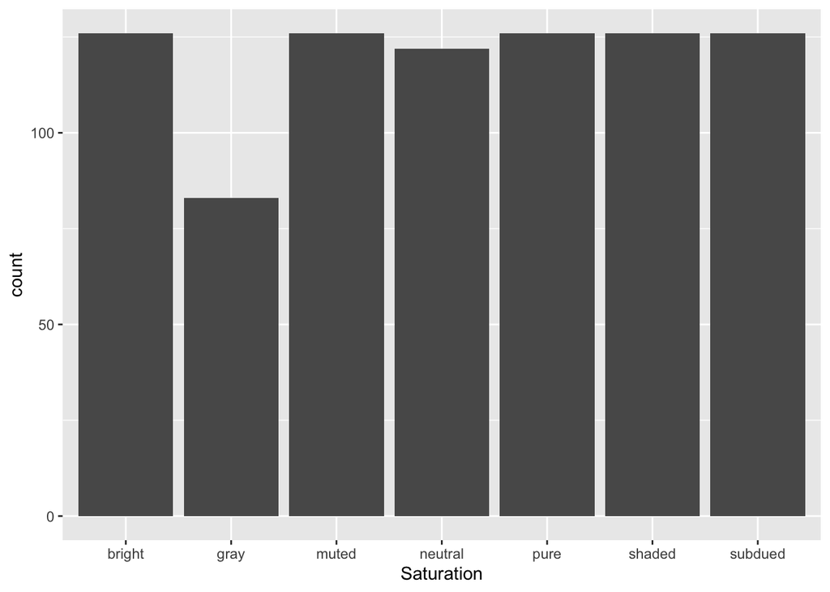

```r
df %>% ggplot(aes(x = Saturation)) + geom_bar()
```

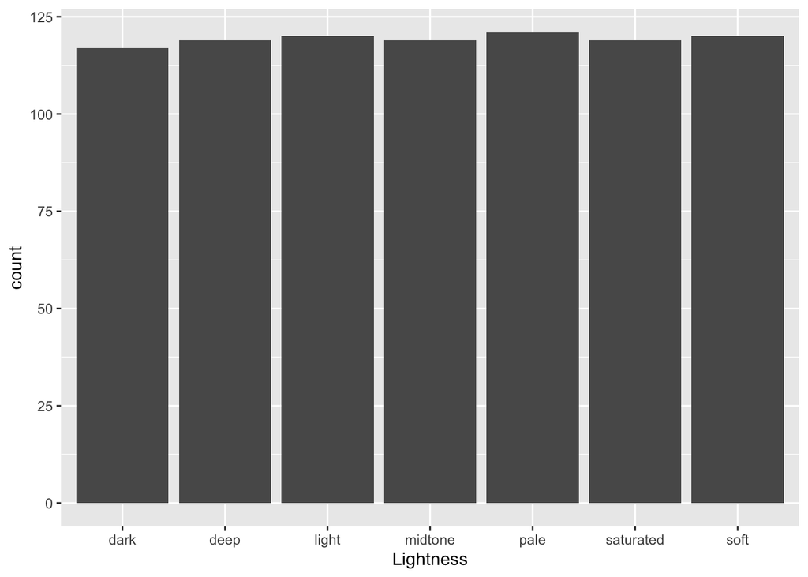

```r
df %>% ggplot(aes(x = Lightness)) + geom_bar()
```

### Condition the continuous variables on the categorical variables

#### Converting to long form

```r
lf <- df %>%
  tibble::rowid_to_column() %>%
  pivot_longer(c(R, G, B, Hue))
```

#### Conditioning based on categorical inputs

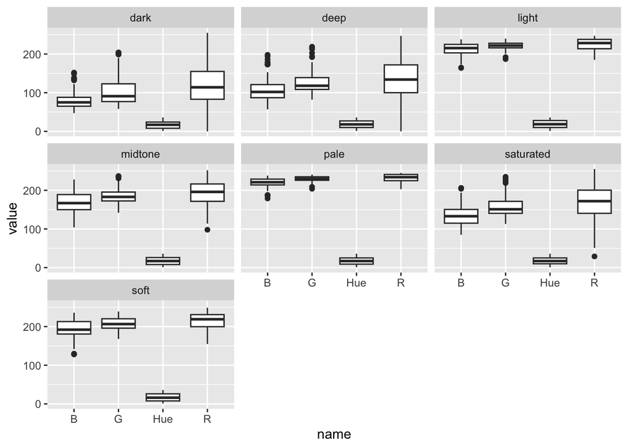

```r
lf %>% ggplot(aes(x = name, y = value)) + geom_boxplot() + facet_wrap( ~ Lightness)
```

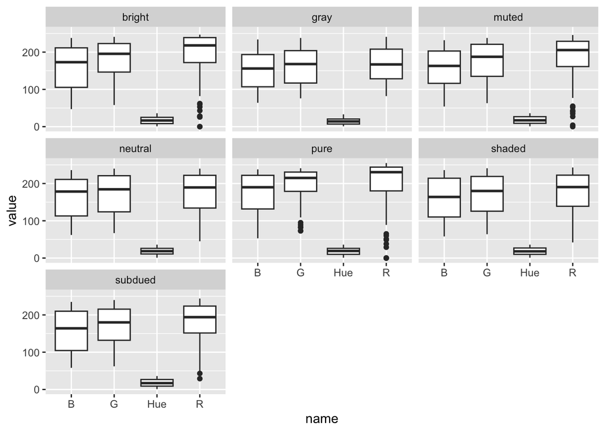

```r
lf %>% ggplot(aes(x = name, y = value)) + geom_boxplot() + facet_wrap( ~ Saturation)
```

#### Conditioning based on the categorical output

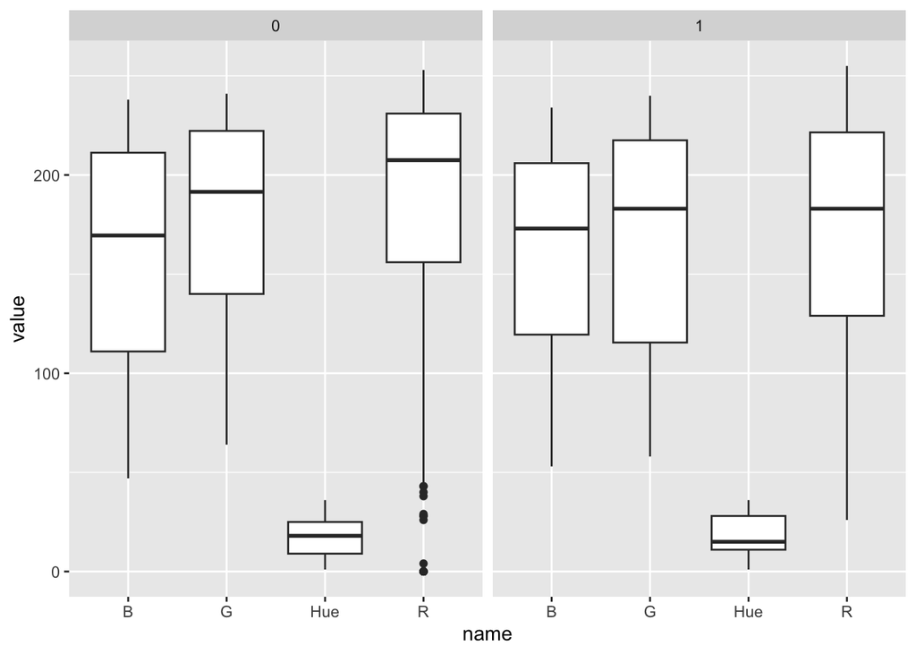

```r
lf %>% ggplot(aes(x = name, y = value)) + geom_boxplot() + facet_wrap( ~ outcome)
```

### Relationship between continuous inputs

#### Correlation plot

```r
df
```

```
## # A tibble: 835 × 8
##        R     G     B Lightness Saturation   Hue response outcome
##    <dbl> <dbl> <dbl> <chr>     <chr>      <dbl>    <dbl>   <dbl>
##  1   172    58    62 dark      bright         4       12       1
##  2    26    88   151 dark      bright        31       10       1
##  3   172    94    58 dark      bright         8       16       1
##  4    28    87   152 dark      bright        32       10       0
##  5   170    66    58 dark      bright         5       11       0
##  6   175    89    65 dark      bright         6       16       0
##  7    90    78   136 dark      bright        34       10       0
##  8   194   106    53 dark      bright        10       19       0
##  9   171    68   107 dark      bright         1       14       0
## 10   122   151    59 dark      bright        21       25       0
## # ℹ 825 more rows
```

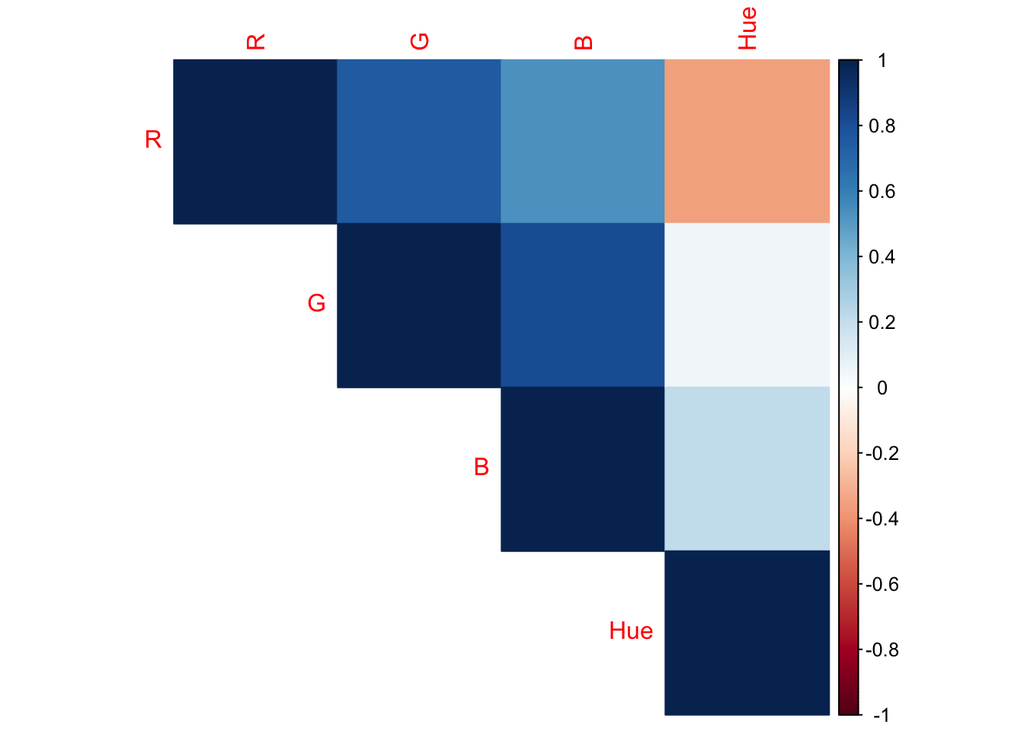

```r
df %>%
  select(R, G, B, Hue) %>%
  cor() %>%
  corrplot::corrplot(type = 'upper',
                     method = 'color')
```

#### Relationship between continuous inputs

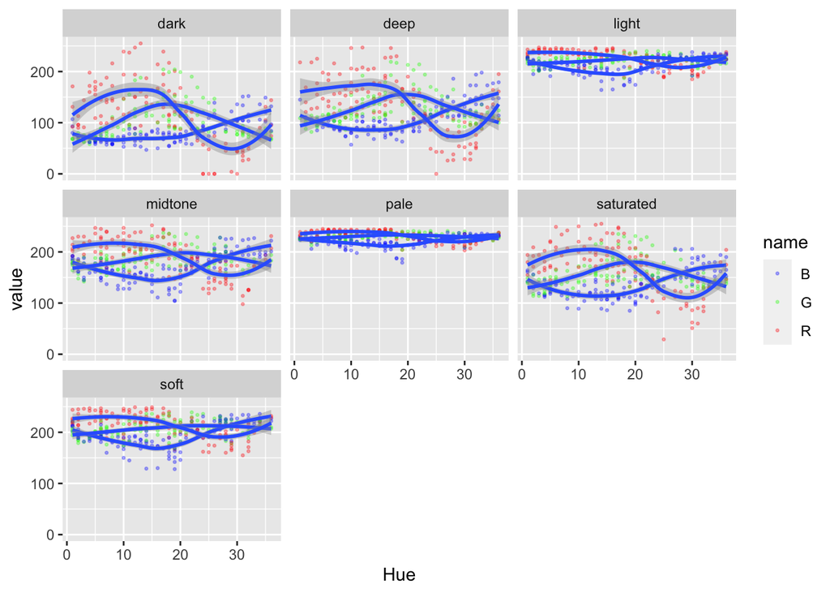

```r
df %>%
  tibble::rowid_to_column() %>%
  pivot_longer(c(R, G, B)) %>%
  ggplot(aes(Hue, value)) +
  geom_point(aes(color = name), alpha = 0.3, size = 0.5) +
  geom_smooth(aes(group = name)) +
  scale_color_manual(values = list(
  R = "red",
  B = "blue",
  G = "green"
)) +
  facet_wrap(~ Lightness)
```

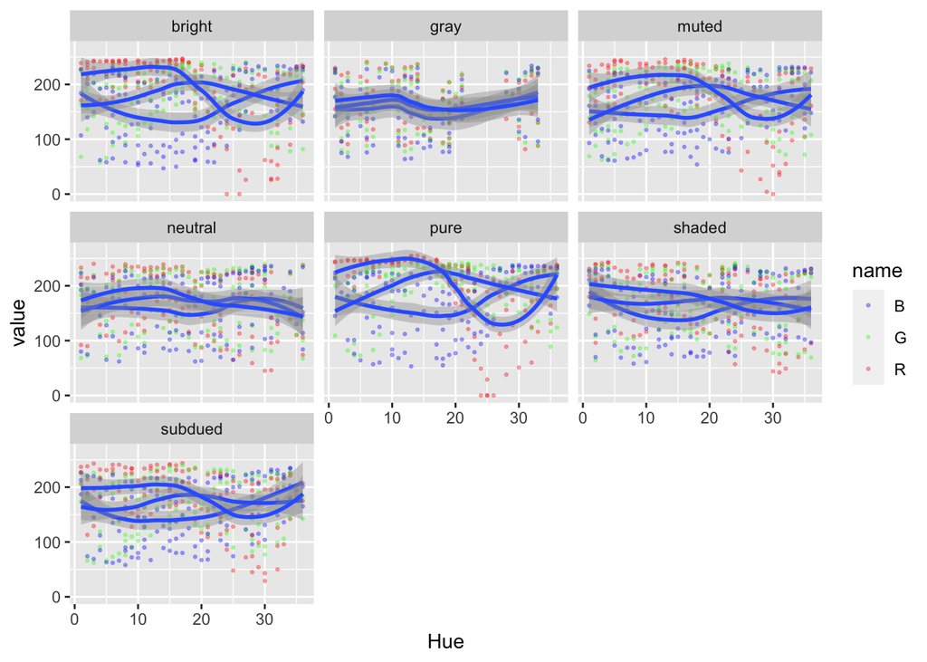

```r
df %>%
  tibble::rowid_to_column() %>%
  pivot_longer(c(R, G, B)) %>%
  ggplot(aes(Hue, value)) +
  geom_point(aes(color = name), alpha = 0.3, size = 0.5) +
  geom_smooth(aes(group = name)) +
  scale_color_manual(values = list(
  R = "red",
  B = "blue",
  G = "green"
)) +
  facet_wrap(~ Saturation)
```

### Relationship between output and input